# MEML_HW03

**Machine Learning for Mechanical Engineering**  
**Homework 03**  
**Due Tuesday, 03/30/2021, 09:30 AM**

TA: Jongmok Lee  
Instructor: Prof. Seungchul Lee  
http://iai.postech.ac.kr/  
Industrial AI Lab at POSTECH

- For your handwritten solution, scan or take a picture of them.
- For your code, only .ipynb file will be graded.
  - Please write your NAME and student ID on your .ipynb files. ex) JongmokLee_20212781_HW03.ipynb
- Please compress all files to make a single .zip file
  - Please write your NAME and student ID on your .zip files. ex) JongmokLee_20212781_HW03.zip
  - Submit it to PLMS
- Do not submit a printed version of your code. It will not be graded.

# Problem 1

Suppose you receive the binary signal. The signal is corrupted with noises while transmitting through channels. We want to get rid of noise from the original signal through the $L_1$ optimization. The mathematical problem statement is given:

$$ \begin{array}{Icr}\begin{align*} y = x + \omega\\ x \in \{ 0, 1 \}\\ \omega \text{ is noise} \end{align*}\end{array} \quad \Longrightarrow \begin{array}{I} \quad \text{Recover original signal } x \text{ from corrupted signal } y \end{array} $$

### Step 1. Data generation

(a) First, generate the original signal of 200 data points as shown in the below figure. This can be simply done using ones and zeros commands in Python.

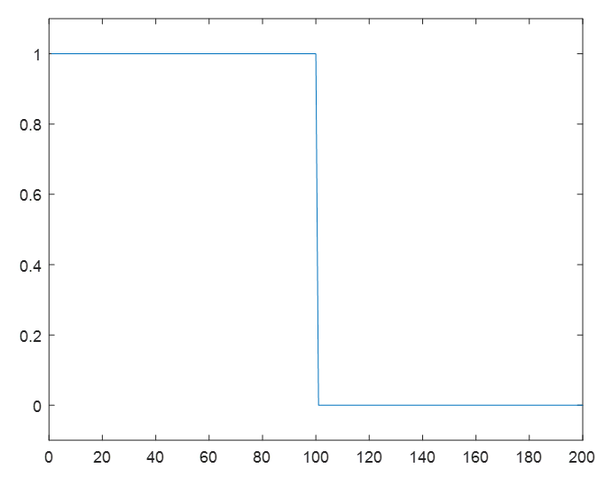

```python
# Write your code here
```

(b) Next, corrupt the original signal with Gaussian noise. This can be done using randn command in Python. One of realizations of the corrupted signal will be given:

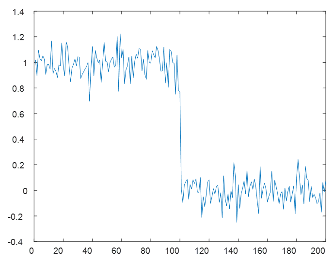

```python
# Write your code here
```

### Step 2. $L_1$ optimization

Note that the signal is sparse (in a sense of frequency domain). Therefore we can apply the $L_1$ optimization. We will optimize the $L_1$ loss function with the $L_2$ constraints.

(c) Plot the reconstructed signal. In addition, by changing $\beta$ in the lecture slide, explain how $\beta$ affects in an optimization process. One of reconstructed signal with a proper value of $\beta$ is shown below:

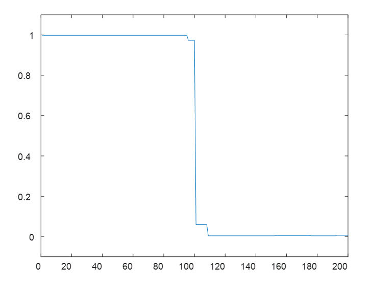

```python
# Write your code here
```

# Problem 2

The regularized least-squares problem has the form

$$ \min_{\theta} \;\lVert A\theta -y\rVert_2^2 + \lambda \lVert \theta \rVert_2^2$$

(a) Show that the solution is given by
$$ \hat{\theta} = \left( A^T A + \lambda I_n \right)^{-1} A^T y $$

- Do not use the method of Lagrangian multipliers

(b) Write down a gradient descent algorithm for the given optimization problem.

- Hint: Note that $$ \;\lVert A\theta -y\rVert_2^2 = (A\theta - y)^T(A\theta - y)$$
  Then, you can differentiate the above equation to compute the gradient. Likewise, you can compute the gradient of the regularizer.

(c) Based on the result of (b), describe the role of regularizer term.

- Hint: Gradient $g$ is computed by $ g = g_{\text{projection}} + g_{\text{regularizer}} $.

(d) Describe results of (a) and (b) have the same meaning.

(e) Find and draw an approximated curve of the given data points below in Python using your gradient descent algorithm.

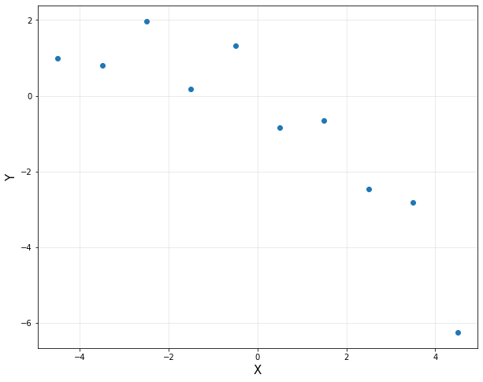

```python
import numpy as np
import matplotlib.pyplot as plt
%matplotlib inline

# 10 data points
n = 10
x = np.linspace(-4.5, 4.5, 10).reshape(-1, 1)
y = np.array([0.9819, 0.7973, 1.9737, 0.1838, 1.3180, -0.8361, -0.6591, -2.4701, -2.8122, -6.2512]).reshape(-1, 1)

plt.figure(figsize = (10, 8))
plt.plot(x, y, 'o', label = 'Data')
plt.xlabel('X', fontsize = 15)
plt.ylabel('Y', fontsize = 15)
plt.grid(alpha = 0.3)
plt.show()
```

```python
# your code here
```

# Problem 3: Image Panorama with Regression

We want to demonstrate an image panorama as an example of linear regression. A panorama is any wide-angle view or representation of a physical space.

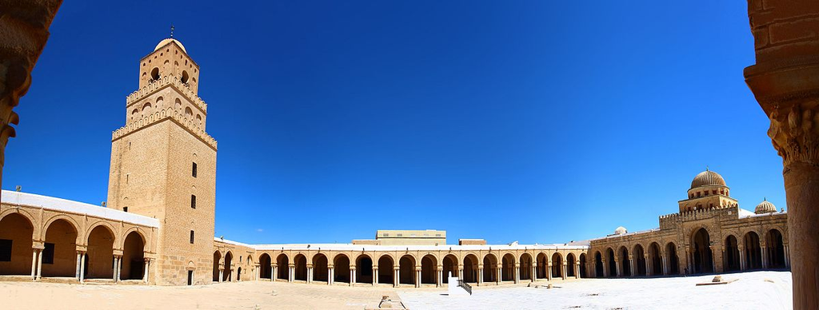

```python
%%html
<center><iframe src="https://www.youtube.com/embed/86rnwu3ZFbE?rel=0"
width="560" height="315" frameborder="0" allowfullscreen></iframe></center>
```

[video not shown]

- You need to install the opencv module and download the images.
- opencv install
  - https://pypi.python.org/pypi/opencv-python
- Image download
  - https://www.dropbox.com/s/vlmp67zlq4mo0um/HW1.zip?dl=1

```python
# import library
import numpy as np
import matplotlib.pyplot as plt
import cv2
```

```python
# load images
imag1 = cv2.imread('./data_files/1.jpg')
imag1 = cv2.cvtColor(imag1, cv2.COLOR_BGR2RGB)
imag2 = cv2.imread('./data_files/2.jpg')
imag2 = cv2.cvtColor(imag2, cv2.COLOR_BGR2RGB)
imag3 = cv2.imread('./data_files/3.jpg')
imag3 = cv2.cvtColor(imag3, cv2.COLOR_BGR2RGB)
```

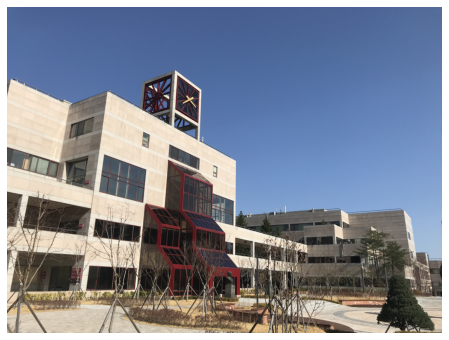

```python
## your code here
```

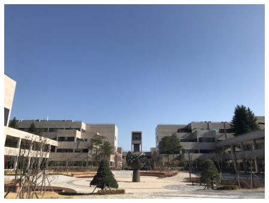

```python
## your code here
```

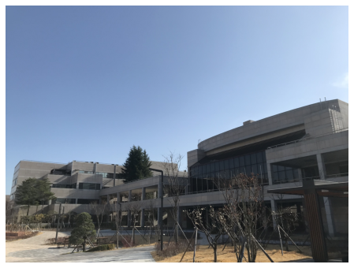

```python
## your code here
```

**Panorama**

Here, we are explaining the basic concept of homography (i.e., perspective transformation).

- Any wide-angle view or representation of a physical space
- images with horizontally elongated fields of view
- idea: projecting images onto a common plane

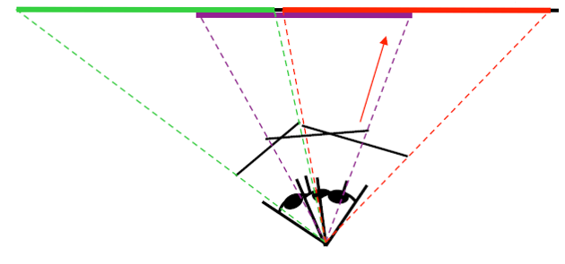

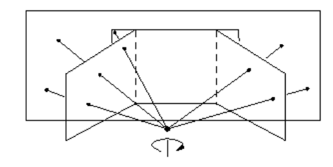

- Camera rotating about its center

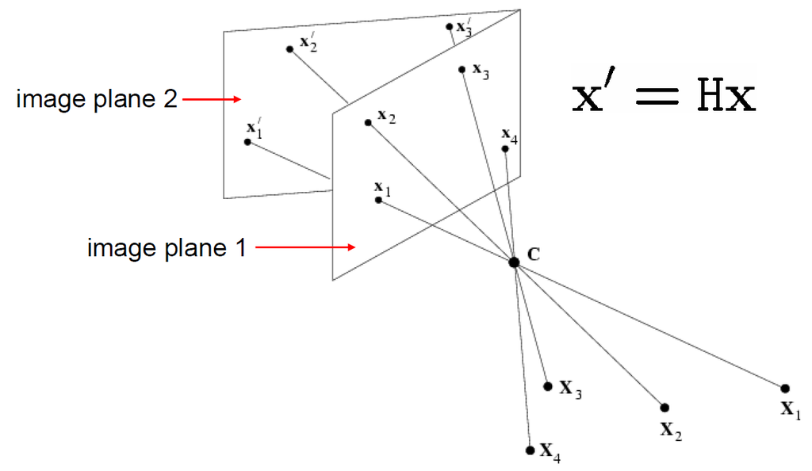

- Two image planes are related by a homography $H$

  Do not worry about a homography transformation. (out of this course's scope)

$$ \begin{bmatrix} x'\\y'\\1 \end{bmatrix} \sim \begin{bmatrix} \omega x'\\\omega y'\\\omega \end{bmatrix} = \begin{bmatrix} a & b & c \\ d & e & f \\ g & h & 1 \end{bmatrix} \begin{bmatrix} x\\y\\1 \end{bmatrix} $$

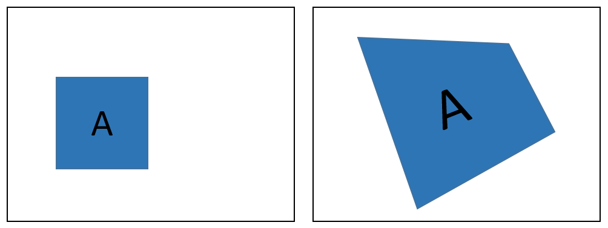

- For the advanced learner, watch the following online lecture by Prof. Aaron Bobick

```python
%%html
<center><iframe src="https://www.youtube.com/embed/pU4NorC7lb0?rel=0"
width="560" height="315" frameborder="0" allowfullscreen></iframe></center>
```

[video not shown]

## Find key points between two images

- Suppose these matching points are given.
  - We have manually found the matching points for you, although there is a technique to do this automatically.
- pos1 and pos2 are matching points between img01 and img02
- pos3 and pos4 are matching points between img02 and img03

```python
pos1 = np.array([[2121, 2117, 2749, 3095, 3032, 3375, 3677, 3876],
                 [1431, 2034, 2033, 1885, 2017, 2037, 1885, 2279]], dtype=np.int64)
pos2 = np.array([[188, 58, 828, 1203, 1121, 1437, 1717, 1817],
                 [1217, 1909, 1952, 1827, 1952, 1991, 1870, 2226]], dtype=np.int64)
pos3 = np.array([[2338, 2379, 2658, 2899, 2977, 3272, 2716, 2786],
                 [1948, 1874, 2000, 1837, 1964, 1966, 2143, 2317]], dtype=np.int64)
pos4 = np.array([[109, 178, 497, 795, 851, 1144, 534, 580],
                 [1907, 1828, 1988, 1834, 1971, 1993, 2145, 2333]], dtype=np.int64)
```

(a) Visualization of key points

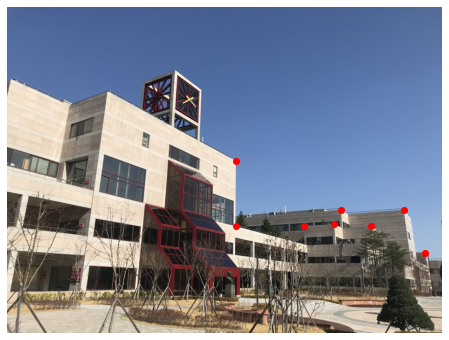

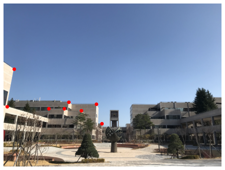

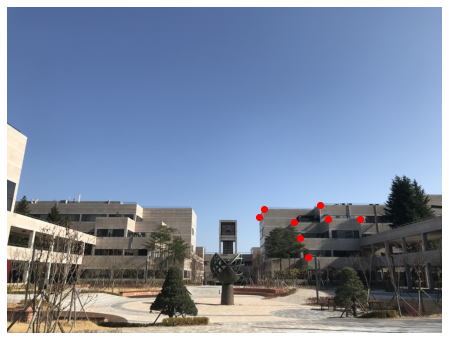

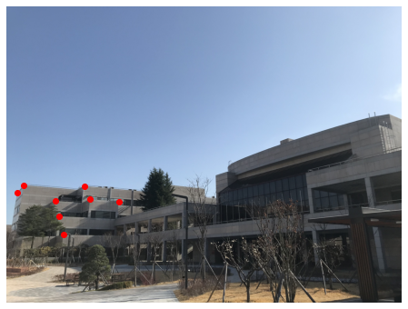

```python
## your code here
## Write down your own code to mark the key points (red dots) on the locations of the given images
```

**Estimation of homography H**

$$ X' = HX $$

where $ X $ and $X'$ are position vectors of key points, and $ H $ is a Perspective Transformation

**Goal: we need to estimate homography $H$ via matching points between two images**

$$\begin{bmatrix} x' \\ y' \\ 1 \end{bmatrix} \sim \begin{bmatrix} \omega x' \\ \omega y' \\ \omega \end{bmatrix} = \begin{bmatrix} \theta_{1} & \theta_{2} & \theta_{3} \\ \theta_{4} & \theta_{5} & \theta_{6} \\ \theta_{7} & \theta_{8} & 1 \end{bmatrix} \begin{bmatrix} x\\ y\\ 1 \end{bmatrix}$$

(b) Show the following equations from the above homography $H$

$$ \begin{align*} x' &= \frac{\theta_1 x+\theta_2 y+\theta_3}{\theta_7 x+\theta_8 y+1} \\ y' &= \frac{\theta_4 x+\theta_5 y+\theta_6}{\theta_7 x+\theta_8 y+1} \end{align*} $$
$$ \begin{align*} \theta_1 x+\theta_2 y+\theta_3 -\theta_7 x'x-\theta_8 x'y-x' &= 0 \\ \theta_4 x+\theta_5 y+\theta_6 -\theta_7 y'x-\theta_8 y'y-y' &= 0 \end{align*} $$

(c) For $m$ pairs of matching potins, show that a feature matrix $\Phi$ can be expressed as follows:

- $ \Phi $ is a feature matrix

$$ \Phi = \begin{bmatrix} x_{1} & y_{1} & 1 & 0 & 0 & 0 & -x'_{1}x_{1} & -x'_{1}y_{1}\\ 0 & 0 & 0 & x_{1} & y_{1} & 1 & -y'_{1}x_{1} & -y'_{1}y_{1}\\ \vdots &\vdots &\vdots &\vdots &\vdots &\vdots &\vdots &\vdots\\ x_{m} & y_{m} & 1 & 0 & 0 & 0 & -x'_{m}x_{m} & -x'_{m}y_{m}\\ 0 & 0 & 0 & x_{m} & y_{m} & 1 & -y'_{m}x_{m} & -y'_{m}y_{m}\end{bmatrix} $$

- $ \theta $ is a column vector for unknown parameters in a perspective transformation $H$

$$ \theta = \begin{bmatrix} \theta_{1} \\ \theta_{2} \\ \theta_{3} \\ \theta_{4} \\ \theta_{5} \\ \theta_{6} \\ \theta_{7} \\ \theta_{8} \end{bmatrix} $$

- $b$ is a column vector for corresponding positions in the base image

$$ b = \begin{bmatrix} x'_{1} \\ y'_{1} \\ x'_{2} \\ y'_{2} \\ \vdots \\ x'_{m} \\ y'_{m} \end{bmatrix} $$

- It ends up becoming a linear regression problem

$$ \min\limits_{\theta} \lVert \Phi\theta - b \rVert _2^2 $$$$ \theta^* = (\Phi^T\Phi)^{-1}\Phi^T b $$

(d) Perspective homography for image 1 and image 2

```python
## your code here
## Construct feature matrix using homography H, and a vector having entries of matching points in image 2




## your code here
## Define perspective_theta using linear regression




perspective_theta = np.vstack([perspective_theta, [1]])
perspective_theta = perspective_theta.reshape(3, 3)
```

(e) Perspective homography for image 2 and image 3

```python
## your code here
## Construct feature matrix using homography H, and a vector having entries of matching points in image 2




## your code here
## Define perspective_theta using linear regression




perspective_theta3 = np.vstack([perspective_theta3, [1]])
perspective_theta3 = perspective_theta3.reshape(3, 3)
```

## Image warping

- Again, do not worry about the image warping (outside lecture's scope)

```python
cv2.warpPerspective?
```

```python
## Apply image warping on image 1 & image 3 using cv2.warpPerspective function

## do translation to fit the warping image into a size of (18000, 6500) screen.
translation = np.matrix([[1, 0, 6000],
                         [0, 1, 2500],
                         [0, 0, 1]])

warpedImage = cv2.warpPerspective(imag1, translation*perspective_theta, (18000, 6500))
warpedImage3 = cv2.warpPerspective(imag3, translation*perspective_theta3, (18000, 6500))
```

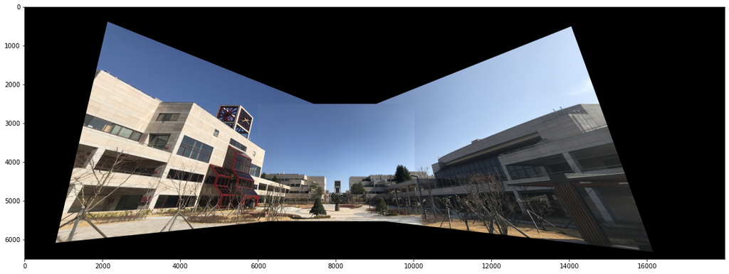

```python
screen = warpedImage.copy()
screen[screen==0] = warpedImage3[screen==0]
screen[2500:3024+2500,6000:4032+6000] = imag2

## Visualize panorama image
plt.figure(figsize=(20, 12))
plt.imshow(screen)
plt.show()
```

# Problem 4

We saw many optimization problems in a machine learning context and witnessed that $L_1$ norm reguarlization provides not only small, but also sparse decision variables. In this problem we will use a linear programming to solve $L_1$ norm optimization problems instead of simply using cvx.

(a) Show that

$$ \lvert y_i \rvert = \max \left(-y_i,y_i \right) $$

(b) Show that, by introducing slack variable $t_i$, the absolute value optimization problem can be coverted to

$$ \begin{array}{} \begin{align*} \min \,\lvert y_i \rvert = \min \left\{\max \left(-y_i,y_i \right) \right\} \end{align*} \end{array} \qquad\iff\qquad \begin{array}{rr} \quad \min \; & t_i \quad \\ \text{subject to} \; &y_i \leq t_i \\ &-y_i \leq t_i \end{array} $$

(c) Suppose $A\theta-b = r$ and $t = \begin{bmatrix} t_1 & t_2 & \cdots & t_m \end{bmatrix}^T $, then show that $L_1$ norm fitting/approximation problem, i.e., sum of (absolute) residuals can be coverted to

$$ \begin{array}{} \begin{align*} \min \,\lVert A\theta-b \rVert_{1} \end{align*} \end{array} \qquad\iff\qquad \begin{array}{rr} \quad \min \; & t_1 + \cdots + t_m \\ \text{subject to} \; & A\theta - b \leq t \\ & -(A\theta - b) \leq t \end{array} $$

(d) Change the above optimization problem to a linear programming (LP) in matrix form where $\mathbb{1} = \begin{bmatrix} 1& \cdots & 1\end{bmatrix}^T$ and $\mathbb{0} = \begin{bmatrix} 0& \cdots & 0\end{bmatrix}^T$

$$ \begin{align*} \min \quad & \begin{bmatrix} \mathbb{0}^T & \mathbb{1}^T \end{bmatrix} \begin{bmatrix} \theta \\ t \end{bmatrix} \\ \text{subject to} \quad & \begin{bmatrix} A & -I \\ -A & -I \end{bmatrix}\begin{bmatrix} \theta \\ t \end{bmatrix} \leq \begin{bmatrix} b \\ -b \end{bmatrix} \end{align*} $$

(e) Use `cvxpy` in Python to find and plot a linear regression for data points with the above formulation

```python
import numpy as np
x = np.array([0.1, 0.4, 0.7, 1.2, 1.3, 1.7, 2.2, 2.8, 3.0, 4.0, 4.3, 4.4, 4.9])
y = np.array([0.5, 0.9, 1.1, 1.5, 1.5, 2.0, 2.2, 2.8, 2.7, 3.0, 3.5, 3.7, 3.9])
```

```python
## your code here
```